# Criminal Site Selection (CSS) Modeling in R

*Sam Huddleston* *April 29, 2016*

This lab provides an introduction to the development of Criminal Site Selection (CSS) models using R statistical software. CSS models are a technique used to develop hot-spot maps to predict future criminal activity. CSS models have been shown to significantly improve predictive performance over traditional kernel density hot-spot methods for predicting crimes such as burglaries [1,2], terrorist events [3], suicide bombings [4], and criminal activity by street gangs [5,6]. It has also been shown to be useful for geographic profiling - finding the anchor point (home or workplace) of criminal offenders [7].

This tutorial consists of six basic steps:

1. Set up the R Programming Environment
2. Import and Organize the Raw Data Files
3. Develop CSS Modeling Data Frames
4. Develop Criminal Site Selection Models
5. Evaluate CSS Model Performance
6. Develop Maps of CSS Model Predictions

### Step 1: Set up the R Programming Environment

Open a new script file in R, give it an appropriate name and paste code blocks that follow as necessary to complete this tutorial. Before we begin bringing data into the R programming environment, we need install and load the geospatial packages that we will use for this lab. The following commands will ensure the right geospatial and modeling packages are installed and loaded.

```
install.packages(c("maptools", "splancs", "spatstat", "rgeos", "rgl", "boot", "aspace", "rgdal", "arm", "randomForest", "raster", leaflet", "RColorBrewer""), dependencies = TRUE)
library(maptools)
library(grid)
library(splancs)
library(spatstat)
library(rgl)
library(boot)
library(aspace)
library(rgdal)
library(rgeos)
library(arm)
```

The next step is to download the raw data and save in an appropriate directory on your computere. Dowload the “Shapefiles.zip” directory, unzip the directory, and point your current working directory to the unzipped directory name “Shapefiles”. In RStudio this is accomplished by clicking: Session -> Set Working Directory -> Choose Directory.

### Step 2: Import and Organize the Raw Data Files

In this lab, we’ll be using the R programming language as a Geographic Information System (GIS). The next step in this process is to bring in the geographic shapefiles that contain the raw data we will use to build and visualize the CSS models. In the shapefiles folder, there are seven shapefiles (note that the gang names have been anonymized in this dataset):

- SA_Outline: an outline of the City of Santa Ana, California
- Gang_Points: a gang intelligence map containing the point locations (addresses) for some of the criminal gangs in the city.
- Gang_Territory: a gang intelligence map containing the “claimed” gang territories for some of the criminal gangs in the city.
- Block_Groups: demographic information at the Census block group level from the 2000 Census
- Streets: a line shapefile street map of the City of Santa Ana, California
- Incidents: a point shapefile of the locations of criminal incidents by the six most violent gangs in the city
- Grid_Points: a point shapefile of a point grid at a high resolution over the City of Santa Ana, which will be used for modeling and visualization

#### Step 2a: Importing Shapefiles Into R

We’ll use the readOGR() function in the rgdal package to read in our shapefiles. Unlike many other functions for reading in shapefiles, the readOGR() function reads the projection and coordinate system of the shapefile, which is very important.

```r
SA.Outline<-readOGR(getwd(),"SA_Outline")
Gang.Points<-readOGR(getwd(), "GangPoints")
Block.Groups<-readOGR(getwd(), "Block_Groups")
Streets<-readOGR(getwd(), "Streets")
Gang.Territory<-readOGR(getwd(), "GangTerritory")
Incidents<-readOGR(getwd(),"Incidents")
Grid.Points<-readOGR(getwd(), "Grid_Points")
```

Shapefiles often have a dataframe contained within them in addition to geographic information. For example, the Incidents shapefile has information about crimes committed by some of the largest and most violent criminal gangs. You can access this dataframe using the “@” operator, which for GIS shapefiles operates much like the “$” operator does for dataframes in R.

```r
summary(Incidents@data)
```

```
##       X_1            X           OBJECTID         CASENO
##  Min.   :  1   Min.   :  17   Min.   :  27   00-04164:  1
##  1st Qu.:102   1st Qu.:1264   1st Qu.:1023   00-04717:  1
##  Median :203   Median :2680   Median :2486   00-04810:  1
##  Mean   :203   Mean   :2682   Mean   :2783   00-05321:  1
##  3rd Qu.:304   3rd Qu.:3950   3rd Qu.:4457   00-06487:  1
##  Max.   :405   Max.   :5464   Max.   :6238   00-07693:  1
##                                              (Other) :399
##        CASEDATE       HOUR_                CITY        CRIMTYPE
##  11/29/1995:  3   Min.   :   5   GARDEN GROVE:  1   Min.   : 2.00
##  1/18/1996 :  2   1st Qu.:1210   SANTA ANA   :404   1st Qu.: 7.00
##  10/1/1997 :  2   Median :1655                      Median :14.00
##  10/7/1994 :  2   Mean   :1524                      Mean   :13.15
##  11/2/1997 :  2   3rd Qu.:2059                      3rd Qu.:20.00
##  11/4/1995 :  2   Max.   :2348                      Max.   :21.00
##  (Other)   :392
##      CRIME1          YEAR_        GangName     Gang_ID
##  Min.   :1.000   Min.   :   0   Gang 1:80   Min.   :1.000
##  1st Qu.:1.000   1st Qu.:1994   Gang 2:66   1st Qu.:2.000
##  Median :1.000   Median :1996   Gang 3:75   Median :3.000
##  Mean   :2.326   Mean   :1740   Gang 4:48   Mean   :3.365
##  3rd Qu.:4.000   3rd Qu.:1998   Gang 5:82   3rd Qu.:5.000
##  Max.   :5.000   Max.   :1999   Gang 6:54   Max.   :6.000
##
```

```r
dim(Incidents@data)
```

```
## [1] 405  12
```

You can access individual columns within the dataframe using the “$” operator:

```r
Incidents@data$CASEDATE[1:10]
```

```
##  [1] 5/23/1995  6/16/1997  1/25/1999  4/22/1999  9/17/1999  6/14/1996
##  [7] 10/7/1995  10/23/1996 5/16/2000  7/5/1995
## 379 Levels: 1/10/1997 1/11/1999 1/13/1998 1/14/1996 1/15/1997 ... 9/8/1995
```

**Take the time to familiarize yourself with the data in each of the shapefile data frames by using the @ operator to look at the different data frames.**

#### Step 2b: Plotting Shapefiles

Once you have read in a shapefile, you can use the basic plot() function to create a map. You can layer shapefiles using the “add = TRUE” as below:

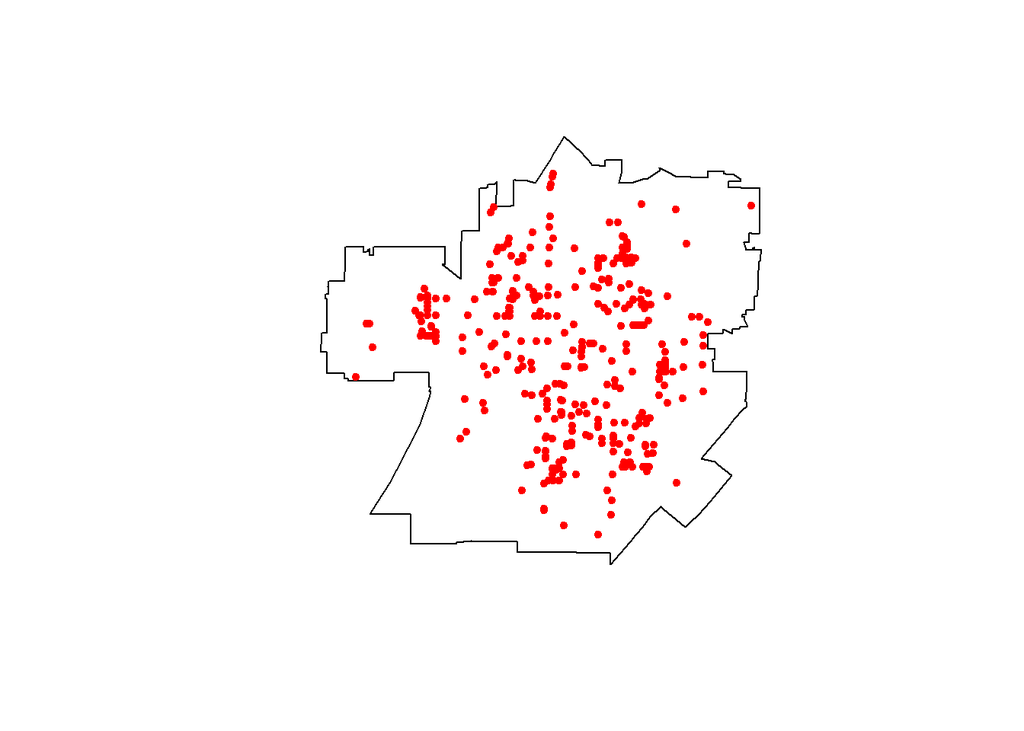

```r
plot(SA.Outline)
plot(Gang.Territory, add=TRUE, col="blue")
plot(Incidents, add=TRUE, col="red", pch=20)
```

Notice in the map above that one of the three layers we attempted to plot does not seem to appear. There doesn’t seem to be any gang territories plotted. There seems to be a problem (and there is). Our map layers are not lining up properly.

#### Step 2c: Transform All Shapefiles to the Same Coordinate System / Projection

The issue here is that geographic information stored in GIS can be stored in many different model formats. Two different shapefiles may be using different models of the world and/or they may be stored in different projections. In order to learn what model the shapefile has, we can use the proj4string() function from the sp package.

```r
proj4string(SA.Outline)
```

```
## [1] "+proj=lcc +lat_1=32.78333333333333 +lat_2=33.88333333333333 +lat_0=32.16666666666666 +lon_0=-116.25 +x_0=2000000 +y_0=500000.0000000002 +datum=NAD83 +units=us-ft +no_defs +ellps=GRS80 +towgs84=0,0,0"
```

```r
proj4string(Gang.Territory)
```

```
## [1] "+proj=longlat +datum=NAD83 +no_defs +ellps=GRS80 +towgs84=0,0,0"
```

Note that these two models/projections are different. We need to transform the Gang.Territories map layer to the same coordinate system as our SA.Outline layer. The spTransform() function provides a way to do this. The code block below transforms all of our map layers to the same projection and coordinate system.

```r
Gang.Points<-spTransform(Gang.Points, CRS(proj4string(SA.Outline)))
Block.Groups<-spTransform(Block.Groups, CRS(proj4string(SA.Outline)))
Streets<-spTransform(Streets, CRS(proj4string(SA.Outline)))
Gang.Territory<-spTransform(Gang.Territory, CRS(proj4string(SA.Outline)))
Incidents<-spTransform(Incidents, CRS(proj4string(SA.Outline)))
```

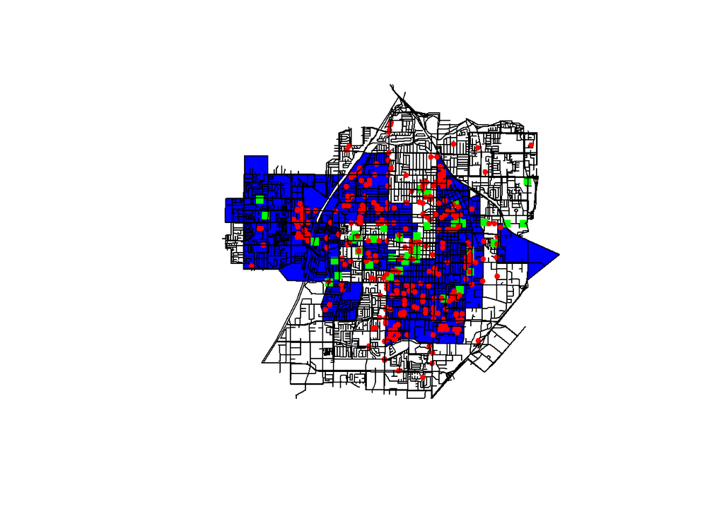

```r
plot(SA.Outline)
plot(Gang.Territory, add=TRUE, col="blue")
plot(Streets, add=TRUE)
plot(Gang.Points, add=TRUE, col="green", pch=15)
plot(Incidents, add=TRUE, col="red", pch=20)
plot(Block.Groups, add=TRUE)
```

### Step 3: Develop CSS Modeling Data Frames

For this lab, we are building CSS models that leverage logistic regression and random forest classification models. The models models require a training dataset that contains observations of where criminals (or criminal gangs) chose to commit crimes and observations of where criminals chose *not* to commit crimes. Therefore, we will have to create two spatial datasets. The first is a dataframe associated with criminal incidents containing spatial predictor variables and a response variable (Response = 1) denoting the occurrence of crime. The second datafame is the “Null Grid” dataframe that represents non-occurrence (Response = 0). We’ll begin by creating the crime occurrence dataset and adding feature space, categorical, and demographic predictors from our spatial datasets.

#### Step 3a: Create a Response Dataframe

The code block below creates a new spatial layer titled “Inc.Data” that has only one feature in its’ dataframe. Note that we can use the “@” operator to assign elements to this spatial layer’s dataframe. Geographically this layer is identical to our Incidents data layer, but it has only one column in its’ dataframe.

```r
Response<-data.frame(rep(1, length(Incidents@data[,1])))
colnames(Response)<-"Response"
Inc.Data<-Incidents
Inc.Data@data<-Response
```

#### Step 3b: Add Feature Space Predictors

The next step is to begin adding predictor variables to the Inc.Data dataframe. The first two predictor variables we will add are *feature space* predictors. Feature space predictors measure the distance between an observation and *key geographic features*. For this lab, we’ll measure the distance to the Gang.Points spatial point layer and the Streets spatial line layer. The nncross() function from the *spatstat* package provides the ability to measure the distance to the nearest point or line feature. Note the use of the as.ppp() and as.psp() functions to denote the difference between the point (as.ppp) and line (as.psp) layers.

```r
DistToGangPnts<-nncross(as.ppp(Inc.Data), as.ppp(Gang.Points))[,1]
DistToStreet<-nncross(as.ppp(Inc.Data), as.psp(Streets))[,1]
```

We now have two new predictor variables for our Inc.Data dataframe stored as vectors. We’ll add them to the dataframe later. For right now, let’s take a look at one of the predictors using the hist() function.

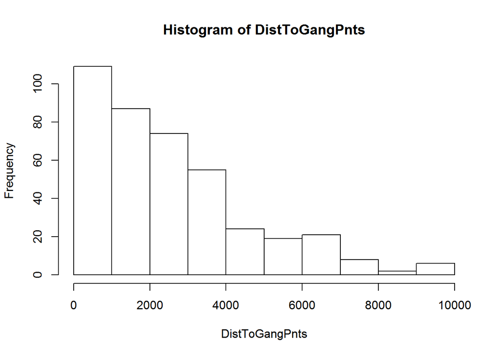

```r
hist(DistToGangPnts)
```

Taking a look at this histogram for DistToGangPnts, we see the motivation for using logistic regression for modeling this problem: the incidence of gang crimes decreases with a classic logistic curve as we move away from gang headquarter locations (as one would expect). Take a second to plot the effect of DistToStreet - this effect is even stronger.

#### Step 3c: Add Categorical Predictors

The next predictor variable we’ll consider is a categorical predictor: Does this incident fall within (or without) a known gang territory? This can be easily checked using the over() function from the *sp* package. The over function returns an “NA” value whenever the point layer doesn’t fall within any one of the polygon layers we are matching against. We can exploit that fact by using the !is.na() function (which literally says, “find things NOT NA”) to create a categorical 1 or 0 predictor variable indicating whether or not an incident falls within a gang territory.

```r
Territory.Check<-over(Inc.Data, Gang.Territory)[,1]
InGangTerr<-vector(mode="numeric", length=length(Territory.Check))
InGangTerr[!is.na(Territory.Check)]<-1
```

#### Step 3d: Add Demographic Predictors

The last kind of information we’ll add is the demographic information from the Census.Blocks layer. We can once again use the over() function to conduct a spatial join between the incident points layer and the Block.Groups layer, assigning all of the properties from each block group to the Inc.Data points that fall within it. The result of this spatial join is a very large (52 columns) dataframe

```r
Inc.Demographics<-over(Inc.Data, Block.Groups)
summary(Inc.Demographics)
```

```
##    OBJECTID_1       ObjectID             SQMI         STATE_FIPS CNTY_FIPS
##  Min.   :  1.0   Min.   :85327872   Min.   :0.03429   06:405     059:405
##  1st Qu.: 50.0   1st Qu.:87883791   1st Qu.:0.09793
##  Median :121.0   Median :98172950   Median :0.14327
##  Mean   :104.8   Mean   :95278027   Mean   :0.23290
##  3rd Qu.:146.0   3rd Qu.:98304006   3rd Qu.:0.20507
##  Max.   :181.0   Max.   :98435088   Max.   :1.62884
##
##   STCOFIPS       TRACT     BLKGRP            FIPS        POP2000
##  06059:405   075002 : 27   1:157   060590750041: 22   Min.   : 713
##              075004 : 27   2:154   060590750023: 15   1st Qu.:1999
##              099249 : 24   3: 73   060590992491: 15   Median :2484
##              074103 : 23   4: 14   060590740031: 13   Mean   :2551
##              074200 : 22   5:  7   060590744032: 13   3rd Qu.:3080
##              074005 : 16           060590742003: 12   Max.   :4779
##              (Other):266           (Other)     :315
##      WHITE          BLACK           AMERI_ES         ASIAN
##  Min.   : 303   Min.   :  1.00   Min.   : 2.00   Min.   :  2.0
##  1st Qu.: 751   1st Qu.: 15.00   1st Qu.:22.00   1st Qu.: 23.0
##  Median : 913   Median : 24.00   Median :31.00   Median : 44.0
##  Mean   :1012   Mean   : 34.21   Mean   :32.89   Mean   :114.7
##  3rd Qu.:1246   3rd Qu.: 45.00   3rd Qu.:40.00   3rd Qu.:160.0
##  Max.   :3007   Max.   :203.00   Max.   :95.00   Max.   :978.0
##
##     HAWN_PI           OTHER        MULT_RACE        HISPANIC
##  Min.   : 0.000   Min.   :  70   Min.   : 33.0   Min.   : 182
##  1st Qu.: 1.000   1st Qu.: 938   1st Qu.: 85.0   1st Qu.:1628
##  Median : 3.000   Median :1133   Median :119.0   Median :2138
##  Mean   : 6.279   Mean   :1229   Mean   :122.3   Mean   :2231
##  3rd Qu.: 9.000   3rd Qu.:1538   3rd Qu.:162.0   3rd Qu.:2705
##  Max.   :43.000   Max.   :2237   Max.   :252.0   Max.   :4376
##
##      MALES         FEMALES       AGE_18_21       AGE_22_29
##  Min.   : 376   Min.   : 328   Min.   : 41.0   Min.   :101
##  1st Qu.:1023   1st Qu.: 966   1st Qu.:144.0   1st Qu.:291
##  Median :1328   Median :1148   Median :183.0   Median :387
##  Mean   :1337   Mean   :1215   Mean   :191.8   Mean   :413
##  3rd Qu.:1650   3rd Qu.:1442   3rd Qu.:242.0   3rd Qu.:516
##  Max.   :2892   Max.   :2305   Max.   :483.0   Max.   :955
##
```

[output cut: 49 more lines]

```
##  Min.   : 1.538   Min.   :0.000000   Min.   :20671   Min.   :   0.0
##  1st Qu.: 4.576   1st Qu.:0.009615   1st Qu.:30278   1st Qu.:   0.0
##  Median : 5.486   Median :0.014019   Median :38125   Median :   0.0
##  Mean   : 5.345   Mean   :0.018089   Mean   :39139   Mean   : 302.5
##  3rd Qu.: 5.976   3rd Qu.:0.019108   3rd Qu.:46607   3rd Qu.: 625.0
##  Max.   :11.270   Max.   :0.807292   Max.   :80000   Max.   :1375.0
##
##      PERPA           PERPoverty          MEDValue        PerOwnOcc
##  Min.   :0.00000   Min.   :0.008037   Min.   :     0   Min.   :0.002786
##  1st Qu.:0.04407   1st Qu.:0.146670   1st Qu.:162200   1st Qu.:0.269774
##  Median :0.07277   Median :0.221526   Median :165000   Median :0.447368
##  Mean   :0.07181   Mean   :0.227838   Mean   :161706   Mean   :0.457538
##  3rd Qu.:0.09038   3rd Qu.:0.301615   3rd Qu.:177500   3rd Qu.:0.685801
##  Max.   :0.17842   Max.   :0.496159   Max.   :479800   Max.   :0.913279
##
```

Taking a look at the summary report (this is a very large dataframe), we can see that we don’t want all of the information from the spatial join. The *demographic predictors* we want to capture are in columns 10 through 52 of the dataframe. The cbind() function allows us to build a matrix of our responses and the predictors we’ve built and then assign this matrix as the datframe to our Inc.Data spatial layer.

```r
Inc.Pred.Matrix<-cbind(Response, DistToGangPnts, DistToStreet, InGangTerr,
                       Inc.Demographics[,10:52])
Inc.Data@data<-Inc.Pred.Matrix
summary(Inc.Data@data)
```

```
##     Response DistToGangPnts      DistToStreet        InGangTerr
##  Min.   :1   Min.   :   4.619   Min.   : 0.09444   Min.   :0.0000
##  1st Qu.:1   1st Qu.: 914.685   1st Qu.: 1.85222   1st Qu.:1.0000
##  Median :1   Median :2133.604   Median : 4.92922   Median :1.0000
##  Mean   :1   Mean   :2574.575   Mean   : 7.52280   Mean   :0.7728
##  3rd Qu.:1   3rd Qu.:3487.820   3rd Qu.:12.28770   3rd Qu.:1.0000
##  Max.   :1   Max.   :9484.804   Max.   :50.56145   Max.   :1.0000
##     POP2000         WHITE          BLACK           AMERI_ES
##  Min.   : 713   Min.   : 303   Min.   :  1.00   Min.   : 2.00
##  1st Qu.:1999   1st Qu.: 751   1st Qu.: 15.00   1st Qu.:22.00
##  Median :2484   Median : 913   Median : 24.00   Median :31.00
##  Mean   :2551   Mean   :1012   Mean   : 34.21   Mean   :32.89
##  3rd Qu.:3080   3rd Qu.:1246   3rd Qu.: 45.00   3rd Qu.:40.00
##  Max.   :4779   Max.   :3007   Max.   :203.00   Max.   :95.00
##      ASIAN          HAWN_PI           OTHER        MULT_RACE
##  Min.   :  2.0   Min.   : 0.000   Min.   :  70   Min.   : 33.0
##  1st Qu.: 23.0   1st Qu.: 1.000   1st Qu.: 938   1st Qu.: 85.0
##  Median : 44.0   Median : 3.000   Median :1133   Median :119.0
##  Mean   :114.7   Mean   : 6.279   Mean   :1229   Mean   :122.3
##  3rd Qu.:160.0   3rd Qu.: 9.000   3rd Qu.:1538   3rd Qu.:162.0
##  Max.   :978.0   Max.   :43.000   Max.   :2237   Max.   :252.0
##     HISPANIC        MALES         FEMALES       AGE_18_21
##  Min.   : 182   Min.   : 376   Min.   : 328   Min.   : 41.0
##  1st Qu.:1628   1st Qu.:1023   1st Qu.: 966   1st Qu.:144.0
##  Median :2138   Median :1328   Median :1148   Median :183.0
##  Mean   :2231   Mean   :1337   Mean   :1215   Mean   :191.8
##  3rd Qu.:2705   3rd Qu.:1650   3rd Qu.:1442   3rd Qu.:242.0
##  Max.   :4376   Max.   :2892   Max.   :2305   Max.   :483.0
##    AGE_22_29     AGE_30_39         MED_AGE        MED_AGE_M
##  Min.   :101   Min.   : 114.0   Min.   :20.50   Min.   :20.90
##  1st Qu.:291   1st Qu.: 341.0   1st Qu.:23.60   1st Qu.:24.10
##  Median :387   Median : 425.0   Median :25.00   Median :25.00
##  Mean   :413   Mean   : 446.9   Mean   :25.29   Mean   :25.31
##  3rd Qu.:516   3rd Qu.: 553.0   3rd Qu.:26.50   3rd Qu.:26.10
##  Max.   :955   Max.   :1163.0   Max.   :39.90   Max.   :38.00
##    MED_AGE_F       HOUSEHOLDS       AVE_HH_SZ       HSE_UNITS
##  Min.   :18.40   Min.   : 191.0   Min.   :1.660   Min.   : 197.0
##  1st Qu.:23.40   1st Qu.: 362.0   1st Qu.:4.490   1st Qu.: 369.0
##  Median :25.00   Median : 452.0   Median :5.400   Median : 470.0
##  Mean   :25.25   Mean   : 495.1   Mean   :5.254   Mean   : 503.3
```

[output cut: 29 more lines]

```
##  Max.   :0.0622407   Max.   :0.11694   Max.   :0.6546   Max.   :0.3394
##     PopPerHH        PERVacant            MEDInc         MEDRent
##  Min.   : 1.538   Min.   :0.000000   Min.   :20671   Min.   :   0.0
##  1st Qu.: 4.576   1st Qu.:0.009615   1st Qu.:30278   1st Qu.:   0.0
##  Median : 5.486   Median :0.014019   Median :38125   Median :   0.0
##  Mean   : 5.345   Mean   :0.018089   Mean   :39139   Mean   : 302.5
##  3rd Qu.: 5.976   3rd Qu.:0.019108   3rd Qu.:46607   3rd Qu.: 625.0
##  Max.   :11.270   Max.   :0.807292   Max.   :80000   Max.   :1375.0
##      PERPA           PERPoverty          MEDValue        PerOwnOcc
##  Min.   :0.00000   Min.   :0.008037   Min.   :     0   Min.   :0.002786
##  1st Qu.:0.04407   1st Qu.:0.146670   1st Qu.:162200   1st Qu.:0.269774
##  Median :0.07277   Median :0.221526   Median :165000   Median :0.447368
##  Mean   :0.07181   Mean   :0.227838   Mean   :161706   Mean   :0.457538
##  3rd Qu.:0.09038   3rd Qu.:0.301615   3rd Qu.:177500   3rd Qu.:0.685801
##  Max.   :0.17842   Max.   :0.496159   Max.   :479800   Max.   :0.913279
```

We now have a complete incident response and predictor variable dataframe. Now, we need to build the exact same dataframe for all of the places crimes did not happen - our null grid point layer. The code block below conducts all of the same calculations we just performed on our incidents data layer on our null grid layer. Note that we assign a “0” (for no incident occurred) as the Response variable in our Null.Data data frame.

```r
Null.Data<-Grid.Points
Response<-data.frame(rep(0, length(Grid.Points@data[,1])))
colnames(Response)<-"Response"

DistToGangPnts<-nncross(as.ppp(Null.Data), as.ppp(Gang.Points))[,1]

DistToStreet<-nncross(as.ppp(Null.Data), as.psp(Streets))[,1]

Territory.Check<-over(Null.Data, Gang.Territory)[,1]
InGangTerr<-vector(mode="numeric", length=length(Territory.Check))
InGangTerr[!is.na(Territory.Check)]<-1

Null.Demographics<-over(Null.Data, Block.Groups)

Null.Pred.Matrix<-cbind(Response, DistToGangPnts, DistToStreet, InGangTerr, Null.Demographics[,10:52])
Null.Data@data<-Null.Pred.Matrix
summary(Null.Data@data)
```

```
##     Response DistToGangPnts       DistToStreet        InGangTerr
##  Min.   :0   Min.   :    7.077   Min.   :   0.002   Min.   :0.0000
##  1st Qu.:0   1st Qu.: 2445.970   1st Qu.:  61.532   1st Qu.:0.0000
##  Median :0   Median : 5522.528   Median : 155.463   Median :0.0000
##  Mean   :0   Mean   : 5939.822   Mean   : 904.960   Mean   :0.2972
##  3rd Qu.:0   3rd Qu.: 9106.720   3rd Qu.: 931.535   3rd Qu.:1.0000
##  Max.   :0   Max.   :17060.429   Max.   :9685.024   Max.   :1.0000
##
##     POP2000          WHITE           BLACK           AMERI_ES
##  Min.   : 713    Min.   : 303    Min.   :  1.00   Min.   : 1.00
##  1st Qu.:1711    1st Qu.: 763    1st Qu.: 21.00   1st Qu.:12.00
##  Median :2211    Median : 996    Median : 30.00   Median :23.00
##  Mean   :2301    Mean   :1027    Mean   : 40.67   Mean   :25.65
##  3rd Qu.:2898    3rd Qu.:1253    3rd Qu.: 53.00   3rd Qu.:35.00
##  Max.   :4779    Max.   :3007    Max.   :203.00   Max.   :95.00
##  NA's   :17032   NA's   :17032   NA's   :17032    NA's   :17032
##      ASIAN           HAWN_PI           OTHER          MULT_RACE
##  Min.   :   2.0   Min.   : 0.000   Min.   :  34.0   Min.   : 23.0
##  1st Qu.:  38.0   1st Qu.: 2.000   1st Qu.: 469.0   1st Qu.: 71.0
##  Median : 105.0   Median : 5.000   Median : 884.0   Median : 94.0
##  Mean   : 214.7   Mean   : 8.847   Mean   : 881.8   Mean   :103.1
##  3rd Qu.: 280.0   3rd Qu.:13.000   3rd Qu.:1199.0   3rd Qu.:136.0
##  Max.   :1871.0   Max.   :54.000   Max.   :2237.0   Max.   :263.0
##  NA's   :17032    NA's   :17032    NA's   :17032    NA's   :17032
##     HISPANIC         MALES          FEMALES        AGE_18_21
##  Min.   :  93    Min.   : 376    Min.   : 328    Min.   : 32.0
##  1st Qu.: 873    1st Qu.: 875    1st Qu.: 838    1st Qu.:100.0
##  Median :1621    Median :1154    Median :1087    Median :151.0
##  Mean   :1644    Mean   :1183    Mean   :1119    Mean   :155.6
##  3rd Qu.:2336    3rd Qu.:1518    3rd Qu.:1408    3rd Qu.:206.0
##  Max.   :4548    Max.   :2892    Max.   :2305    Max.   :483.0
##  NA's   :17032   NA's   :17032   NA's   :17032   NA's   :17032
##    AGE_22_29       AGE_30_39         MED_AGE        MED_AGE_M
##  Min.   : 55.0   Min.   : 114.0   Min.   :20.50   Min.   :20.70
##  1st Qu.:254.0   1st Qu.: 298.0   1st Qu.:25.00   1st Qu.:25.00
##  Median :334.0   Median : 393.0   Median :26.60   Median :26.80
##  Mean   :357.7   Mean   : 409.8   Mean   :28.32   Mean   :27.92
##  3rd Qu.:438.0   3rd Qu.: 525.0   3rd Qu.:30.90   3rd Qu.:30.40
##  Max.   :955.0   Max.   :1163.0   Max.   :43.60   Max.   :43.40
##  NA's   :17032   NA's   :17032    NA's   :17032   NA's   :17032
```

[output cut: 41 more lines]

```
##  Min.   :0.000   Min.   : 19107   Min.   :   0.0   Min.   :0.000
##  1st Qu.:0.009   1st Qu.: 35598   1st Qu.:   0.0   1st Qu.:0.024
##  Median :0.016   Median : 44722   Median : 325.0   Median :0.049
##  Mean   :0.054   Mean   : 46729   Mean   : 445.3   Mean   :0.052
##  3rd Qu.:0.028   3rd Qu.: 54758   3rd Qu.: 900.0   3rd Qu.:0.073
##  Max.   :1.732   Max.   :102297   Max.   :1375.0   Max.   :0.178
##  NA's   :17032   NA's   :17032    NA's   :17032    NA's   :17032
##    PERPoverty       MEDValue        PerOwnOcc
##  Min.   :0.003   Min.   :     0   Min.   :0.003
##  1st Qu.:0.081   1st Qu.:155600   1st Qu.:0.343
##  Median :0.163   Median :173400   Median :0.535
##  Mean   :0.171   Mean   :169623   Mean   :0.517
##  3rd Qu.:0.243   3rd Qu.:195000   3rd Qu.:0.721
##  Max.   :0.514   Max.   :479800   Max.   :0.923
##  NA's   :17032   NA's   :17032    NA's   :17032
```

### Step 4: Develop Criminal Site Selection Models

The next step is to build CSS models from the data. We’ll have to do a little data cleaning and organizing in order to ensure that our models execute. We also need to split our data into training and test datasets so that we can conduct a valid assessment of the performance of our model.

#### Step 4a: Clean and Split Incidents into Training and Test Sets

Because the gang incidents we are considering are occurring over time, we want to evaluate whether or not we can use the crimes we’ve observed in the past to *predict* the location of crimes in the future. So, we need to split our dataset into training and test datasets that represent the way we will use the model. What we’ll do is split our data as of 12/31/98. All incidents that occurred on or before this data will be used to build the model. Incidents that occur after this date will be used to test the model performance. The code block below uses the as.Date() function to properly format the CASEDATE field. We then use the original incident dataframe to determine where to split our Inc.Data dataframe appropriately.

```r
#Split Incidents into Training and Test Sets

Incidents@data$CASEDATE<-as.Date(as.character(Incidents@data$CASEDATE), format="%m/%d/%Y")

Incidents.Test<-Inc.Data[Incidents@data$CASEDATE > as.Date("12/31/1998", format="%m/%d/%Y"),]
dim(Incidents.Test@data)
```

```
## [1] 110  47
```

```r
Incidents.Train<-Inc.Data[Incidents@data$CASEDATE < as.Date("1/1/1999", format="%m/%d/%Y"),]
dim(Incidents.Train@data)
```

```
## [1] 295  47
```

#### Step 4b: Clean and Split the Null Grid

We’ll need to perform the same cleaning and splitting function on the Null grid, although in this case, rather than splitting the null grid over time, we’ll sample it to get a representative sample of places where crime did not happen to use in our trianing and test sets. This sampling is important because the modeling function will not perform well if occurrence events are too rare.

First, let’s remove points that don’t fall within Santa Ana (we don’t want to use those to build our model with, although they will become useful later for visualization). We’ll use the over() function we’ve used before.

```r
Null.Data.SA<-Null.Data[!is.na(over(Null.Data, SA.Outline)[,1]),]
dim(Null.Data.SA)
```

```
## [1] 29798    47
```

Now, let’s remove any records that don’t have complete information in them. The complete.cases() function fromt the *stats* package ensures that we have no lurking “NA” values in our data frame. Note that the resulting data frame may be the same size. This is just a good check to run before building modeling data frames.

```r
Null.Data.Cleaned<-Null.Data.SA[complete.cases(Null.Data.SA@data),]
dim(Null.Data.Cleaned)
```

```
## [1] 29602    47
```

Now we sample for training and test sets.

```r
# Sample for the Train Dataset
Null.Train<-Null.Data.Cleaned[sample(seq(1,dim(Null.Data.Cleaned)[1],by=1), 5000),]
dim(Null.Train)
```

```
## [1] 5000   47
```

```r
# Sample for the Test Dataset
Null.Test<-Null.Data.Cleaned[sample(seq(1,dim(Null.Data.Cleaned)[1],by=1), 5000),]
dim(Null.Test)
```

```
## [1] 5000   47
```

#### Step 4c: Combine Incident/Null Datasets to Form Train/Test Datasets

Now we must simply put our train and test datasets together.

```r
Train.Data<-rbind(Null.Train@data, Incidents.Train@data)
dim(Train.Data)
```

```
## [1] 5295   47
```

```r
Test.Data<-rbind(Null.Test@data, Incidents.Test@data)
dim(Test.Data)
```

```
## [1] 5110   47
```

#### Step 4d: Build Some Models

After the significant work we’ve done to put together our datasets, the modeling may seem anticlimactic. To use a logistic regression in R, we use the glm() function from the *stats* package. For example, the code block below creates a model that performs logistic regression using our feature space predictors DistToGangPnts, DistToStreet, and InGangTerr to predict the Response variable. The summary() function gives us a model summary. Note that because we sampled the null grid to build our datasets, your coefficient estimates may vary from those shown below.

```r
Model.1<-glm(Response ~ DistToGangPnts + DistToStreet + InGangTerr, family="binomial", data=Train.Data)
summary(Model.1)
```

```
##
## Call:
## glm(formula = Response ~ DistToGangPnts + DistToStreet + InGangTerr,
##     family = "binomial", data = Train.Data)
##
## Deviance Residuals:
##     Min       1Q   Median       3Q      Max
## -1.4792  -0.0966  -0.0042   0.0000   3.6945
##
## Coefficients:
##                  Estimate Std. Error z value Pr(>|z|)
## (Intercept)    -1.668e-01  2.092e-01  -0.797 0.425464
## DistToGangPnts -1.230e-04  3.729e-05  -3.299 0.000972 ***
## DistToStreet   -1.290e-01  8.602e-03 -14.998  < 2e-16 ***
## InGangTerr      1.025e+00  1.723e-01   5.951 2.67e-09 ***
## ---
## Signif. codes:  0 '***' 0.001 '**' 0.01 '*' 0.05 '.' 0.1 ' ' 1
##
## (Dispersion parameter for binomial family taken to be 1)
##
##     Null deviance: 2276.9  on 5294  degrees of freedom
## Residual deviance: 1158.0  on 5291  degrees of freedom
## AIC: 1166
##
## Number of Fisher Scoring iterations: 11
```

The next code block uses stepwise regression. First we create a model that uses all predictors (which fails some tests for validity) and then use the step() function from the *stats* package to confirm on a model that uses an optimal set of predictor variable. The model return is not shown here as it is several hundred lines of messages about the fitting of the stepwise procedure.

```r
Model.2<-glm(Response ~., family="binomial", data=Train.Data)
summary(Model.1)

Model.3<-step(Model.2)
summary(Model.3)
```

The last model we will fit is a random forest model (which often works well in situations where we have many predictor variables we’d like to sort through). The code block below installs and loads the *randomForest* package and then uses it to generate a random forest model. Note that we need to use the as.factor() function to ensure that randomForest() fits a classification model rather than a regression model.

```r
library(randomForest)
Model.4<-randomForest(as.factor(Response) ~., data=Train.Data)
summary(Model.4)
```

```
##                 Length Class  Mode
## call                3  -none- call
## type                1  -none- character
## predicted        5295  factor numeric
## err.rate         1500  -none- numeric
## confusion           6  -none- numeric
## votes           10590  matrix numeric
## oob.times        5295  -none- numeric
## classes             2  -none- character
## importance         46  -none- numeric
## importanceSD        0  -none- NULL
## localImportance     0  -none- NULL
## proximity           0  -none- NULL
## ntree               1  -none- numeric
## mtry                1  -none- numeric
## forest             14  -none- list
## y                5295  factor numeric
## test                0  -none- NULL
## inbag               0  -none- NULL
## terms               3  terms  call
```

### Step 5: Evaluate CSS Model Performance

A surveillance plot records the amount of surface area predicted by a model a security agency would need to monitor in order to observe a corresponding percentage of incidents occurred and is an adaptation of a model comparison metric introduced by Smith and Brown [4]. A modelâs tradeoff in accuracy and precision as shown in a surveillance plot is a very important characteristic for evaluating geospatial model performance because we desire a model that focuses security efforts in as small a geographic area as possible.

A surveillance plot is created by rank ordering all of the points on a modelâs general predicted threat surface in descending order from the most likely to the least likely location. The horizontal axis of the surveillance plot records the percentage of surface area, referenced in descending order of threat surface, needed to observe the corresponding percentage of actual incidents in the data set.

The surveillance plot evaluates the performance of the model in the same way that an ROC curve does, except that it couches the evaluation in terms of evaluating the efficiency of a model in allocating resources expended by a security agency in attempting to observe or interdict the crimes as they occur. The best model is the one that achieves the highest percentage of observed incidents for a given percentage of high probability surface area required. The appropriate point of evaluation on the surveillance plot graph is contingent upon the resources available to the evaluating agency. For instance, if it is possible to monitor only 5% of the surface area in the research area with your available resources, then the model that provides the highest number of observed incidents in the test set in 5% or less of the high-probability surface area observed is the best one for your organization.

The code block below creates a function that can be used to generate a surveillance plot for a given model.

```r
survplot<-function(prediction, response){
  SurvPlotData<-cbind(prediction,response)
  SurvPlotData2<-SurvPlotData[order(-prediction),]
  SurvPlotPerc<-vector(mode="numeric", length=length(prediction))
  SurvPlotArea<-vector(mode="numeric", length=length(prediction))
  total<-sum(response)
  for (i in 1:length(prediction)){
    SurvPlotPerc[i]<-sum(SurvPlotData2[1:i,2])/total
    SurvPlotArea[i]<-i/length(response)
  }
  SurvPlot<-cbind(SurvPlotArea, SurvPlotPerc)
  SurvPlot}
```

We test our model performance on the *Test Dataset*. To generate predictions using our model, we use the predict() function. The code block below generates a vector of predictions using three different models on the Test.Data dataframe. This results in predictions on data the model has not previously seen.

```r
M1.prediction<-as.vector(invlogit(predict(Model.1, newdata=Test.Data)))
head(M1.prediction)
```

```
## [1] 4.156701e-03 1.572175e-01 2.757494e-06 5.142981e-17 8.354842e-09
## [6] 3.135187e-03
```

```r
M3.prediction<-as.vector(invlogit(predict(Model.2, newdata=Test.Data)))
head(M3.prediction)
```

```
## [1] 5.014523e-03 4.042512e-02 2.216529e-06 7.579728e-18 1.723238e-09
## [6] 9.915153e-04
```

```r
Test.response<-Test.Data$Response
```

```r
M4.prediction<-predict(Model.4, newdata=Test.Data, type="prob")
head(M4.prediction)
```

```
##           0     1
## 15016 1.000 0.000
## 34764 0.918 0.082
## 12172 1.000 0.000
## 4627  1.000 0.000
## 31879 1.000 0.000
## 2074  1.000 0.000
```

```r
M4.prediction<-predict(Model.4, newdata=Test.Data, type="prob")[,2]
```

Now, we can leverage our survplot() function in order to generate a surveillance plot of our model performance (see below). Note that because we are using R as a GIS system, our normal simple plot function has been usurped necessitating the more awkward plotting statement below (i.e. plot(M1.Survplot) should work but won’t).

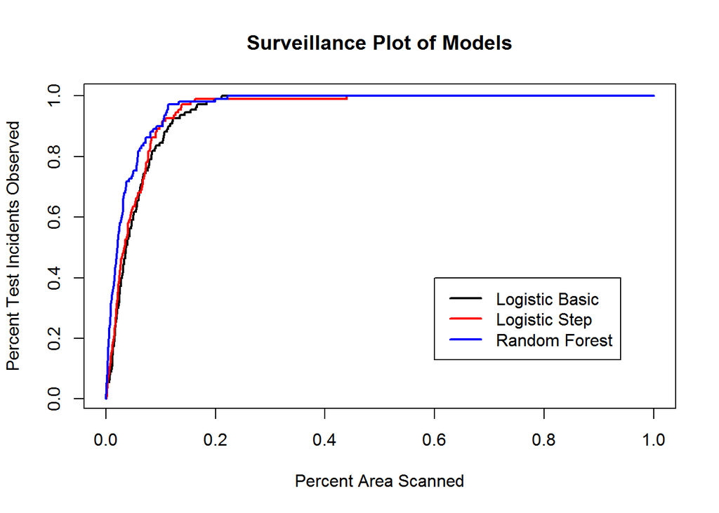

```r
Test.response<-Test.Data$Response
M1.Survplot<-survplot(M1.prediction, Test.response)
M3.Survplot<-survplot(M3.prediction, Test.response)
M4.Survplot<-survplot(M4.prediction, Test.response)

plot(M1.Survplot[,1], M1.Survplot[,2], type="l", lwd=2,
     main="Surveillance Plot of Models", xlab="Percent Area Scanned",
     ylab= 'Percent Test Incidents Observed')
lines(M3.Survplot[,1], M3.Survplot[,2], type="l", lwd=2, col="red")
lines(M4.Survplot[,1], M4.Survplot[,2], type="l", lwd=2, col="blue")
legend(x=.6, y=.4, c("Logistic Basic", "Logistic Step", "Random Forest"), col=c("black", "red", "blue"), lwd=c(2,2,2))
```

Let’s revise our plot to look at the region we care the most about. We can probably cover no more than 20% of the city with surveillance if we flooded all our assets, so the region of the plot we care about the most is the first 20% on the x axis. The code block below plots only that region of the surveillance plot.

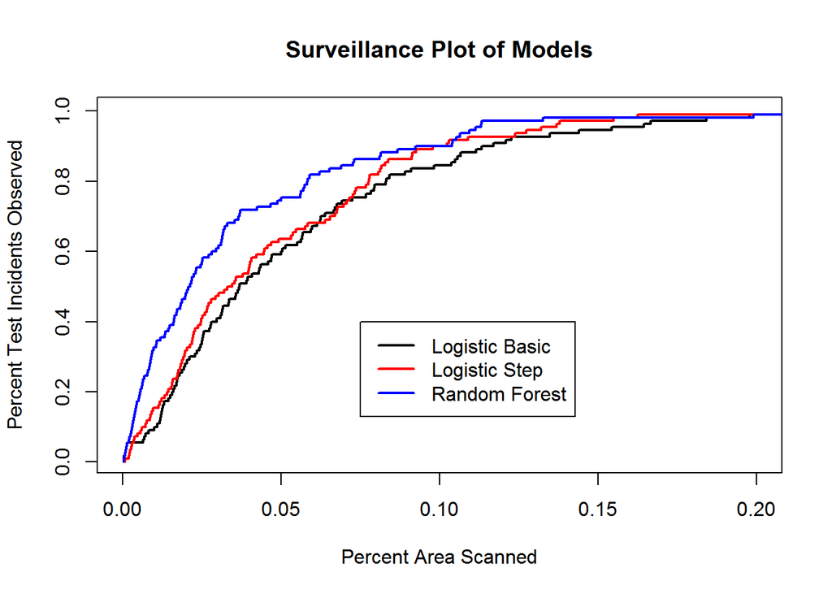

```r
plot(M1.Survplot[,1], M1.Survplot[,2], type="l", lwd=2,
     main="Surveillance Plot of Models", xlab="Percent Area Scanned",
     ylab= 'Percent Test Incidents Observed', xlim=c(0,.2))
lines(M3.Survplot[,1], M3.Survplot[,2], type="l", lwd=2, col="red")
lines(M4.Survplot[,1], M4.Survplot[,2], type="l", lwd=2, col="blue")
legend(x=.075, y=.4, c("Logistic Basic", "Logistic Step", "Random Forest"), col=c("black", "red", "blue"), lwd=c(2,2,2))
```

We can see that the random forest model is clearly outperforming the other two models on the surveillance plot early in our search (i.e. if we surveil the top 5% of the geographic area recommended by the model, during the testing period we would observe about 75% of incidents with the random forest model vs. about 60% of the incidents with the stepwise logistic regression model).

### Step 6: Develop Maps of CSS Model Predictions

We now want to **use our best modeling approach and all of our data** to generate a model to predict future events. So, we’ll neeed to put together a final training dataset that contains all of the observations:

```r
######### Build model on ALL Observations
Train.Data.Final<-rbind(Null.Train@data, Inc.Data@data)
```

We now fit a model using all of our data:

```r
Model.5<-randomForest(as.factor(Response) ~., data=Train.Data.Final)
```

We run a quick check to make sure we are using the correct classification column when we predict on the null grid (we want the column for “class” 1):

```r
head(predict(Model.5, newdata=Train.Data.Final, type="prob"))
```

```
##       0 1
## 40549 1 0
## 36513 1 0
## 36308 1 0
## 32663 1 0
## 8136  1 0
## 37541 1 0
```

As before, we need column 2. Now, We make a “threat surface” map that can be used to identify where these criminal gangs will be most active. To do so, we will leverage our final model, the null grid, and convert our grid from a point shapefile into a raster image.

First, we make a prediction on the complete null grid. Because much of the null grid has incomplete data (it lies outside of Santa Ana) we have to use the is.na function to replace the “NA”s that result when we try to predict with no data.

```r
Prediction<-predict(Model.5, newdata=Null.Data, type="prob")[,2]
Prediction[is.na(Prediction)]<-0
```

Now we add our prediction to the null grid data frame.

```r
Null.Data@data<-cbind(Null.Data@data, Prediction)
summary(Null.Data@data) #Just to make sure it is there
```

The next step is to create a raster image layer over the extent of Santa Ana. We will then use the rasterize() function from the *raster* package to convert our point layer into a raster image that reflects the relative risk of the different locations. Note that we’ve waited to load the *raster* package until now because it depracates some of the functions in other packages we’ve used up to this point (in a bad way).

```r
library(raster)
r <- raster(ncol=200, nrow=200)
extent(r) <- extent(SA.Outline)
Prediction.Raster<- rasterize(Null.Data, r, 'Prediction')
```

Finally, we plot a picture of the results, using our shapefiles to help us orient to the terrain.

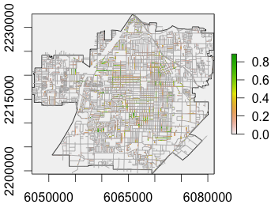

```r
plot(Prediction.Raster)
plot(SA.Outline, add=TRUE)
plot(Streets, add=TRUE, col="darkgrey", cex=.5)
```

This plot is not that useful as it is hard to see exactly what is going on. However, we can use the *leaflet* package to build an interactive visualization of our prediction. The *RColorBrewer* package allows us to quickly build a color palette for our predictions using the brewer.pal() function. We can use the *htmlwidgets* package (called by leaflet) to write out our map to an html page that can be shared with others. In the example below, we use a nice greyscale street map tile called Stamen.Toner to create the map background.

```r
library(leaflet)
library(RColorBrewer)

#Set the projection for our raster and street map
crs(Prediction.Raster) <- sp::CRS(proj4string(SA.Outline))

#Add color palette using RColorBrewer
palette<-brewer.pal(8, "Reds")
pal <- colorNumeric(palette, values(Prediction.Raster),
                    na.color = "transparent")

#Define Lat-Long for our plot using extent()
Latitude=mean(extent(Streets)[1:2])
Longitude=mean(extent(Streets)[3:4])

#Plot using leaflet()
my.map<-leaflet() %>%
   setView(Latitude, Longitude, zoom = 12) %>%
   addProviderTiles("Stamen.Toner") %>%
   addRasterImage(Prediction.Raster, colors = pal, opacity = .8) %>%
   addLegend(pal = pal, values = values(Prediction.Raster),
         title = "Prediction")
my.map   #to plot the map

#To save the map as an html
htmlwidgets::saveWidget(mymap, "SALeafletGangMap.html", selfcontained=TRUE)
```

[figure not shown]

**The final result of our analysis is an interactive map that can be used to prioritize targeting and surveillance resources.**

#### References:

[1] Liu, H., Brown, D.E.: A new point process transition density model for space-time event prediction. IEEE Transactions on Systems, Man, and Cybernetics, Part C: Applications and Reviews 34, 310â“324 (2004)

[2] Xue, Y., Brown, D.E.: Spatial analysis with preference specification of latent decision makers for criminal event prediction. Decision Support Systems 41(3) (2006)

[3] Brown, D.E., Dalton, J., Hoyle, H.: Spatial forecast methods for terrorist events in urban environments. In: Second Symposium on Intelligence and Security Informatics (June 2004)

[4] Smith, M.A., Brown, D.E.: Application of discrete choice analysis to attack point patterns. Information Systems and e-Business Management 5(3) (June 2007)

[5] Huddleston, S.H., Brown, D.E.: A statistical threat assessment. IEEE Transactions on Systems, Man, and Cybernetics - Part A: Systems and Humans 39(6) (2009)

[6] Huddleston, S.H., Fox, J., Brown, D.E.: Mapping gang spheres of influence. Crime Mapping: A Journal of Research and Practice 4(2) (2012)

[7] Huddleston, S.H., Gerber, M.S., Brown, D.E “Geographic Profiling of Criminal Groups for Military Cordon and Search”, Social Computing, Behavioral-Cultural Modeling and Prediction, 503-512 (2014)